# WB1 - Homework 1

Mariusz Słapek

31/03/2020

## Introduction

Reproducibility is a primary component of the scientific method. Full reproducibility means that simply reading a scientific paper should give you all the information you need to: 1. set up the same experiments, 2. follow the same approach, and then 3. obtain similar results. In this article there are two example of two package to reproduce in R.

## corr2D

Implementation of Two-Dimensional Correlation Analysis in R

### Info

In the package corr2D two-dimensional correlation analysis is implemented in R. The package corr2D offers the possibility to preprocess, correlate and postprocess spectroscopic data using exclusively the R language

### Tests

```r
library("corr2D")
library("microbenchmark")
library("profr")
library("xtable")
```

#### Section 2: Theoretical description of 2D correlation spectroscopy

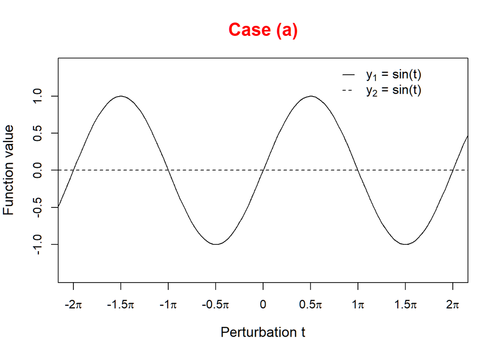

```r
xlab <- c(expression(paste("-2", pi)), expression(paste("-1.5", pi)),
          expression(paste("-1", pi)), expression(paste("-0.5", pi)),
          expression(paste("0")), expression(paste("0.5", pi)),
          expression(paste("1", pi)), expression(paste("1.5", pi)),
          expression(paste("2", pi)))
Pert <- seq(-4*pi, 4*pi, 0.1)

y1 <- sin(Pert)
y2 <- sin(Pert)

plot(Pert, y1, t = "l", col = 1,
     xlab = "Perturbation t", ylab = "Function value", axes = FALSE,
     xlim = c(-2*pi, 2*pi), ylim = c(-1.4, 1.4),
     cex.lab = 1.2, cex.axis = 1.1)
lines(Pert, y2, col = 1, lty = 2)
title("Case (a)", col.main = 2, cex.main = 1.5)
axis(1, seq(-2*pi, 2*pi, pi/2), xlab, cex = 1.1)
axis(2, seq(-1, 1, 0.5), cex = 1.1)
abline(h = 0, lty = 2)
box()

legend(0.8 * pi, 1.5, c(expression(paste(y[1], " = sin(t)")),
                        expression(paste(y[2], " = sin(t)"))),
       col = 1, pch = NA, lty = c(1, 2), bty = "n", seg.len = 1, cex = 1.1)
```

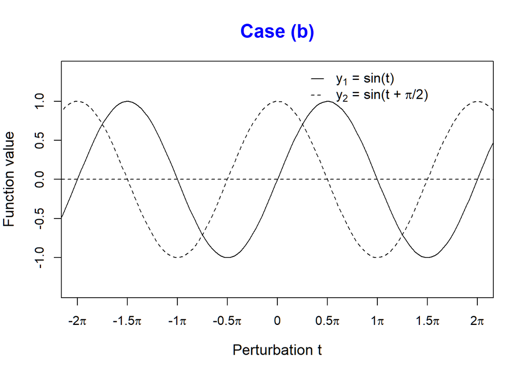

```r
ft1 <- fft(y1)[1:(length(y1) - 1) %/% 2 + 1]
ft2 <- fft(y2)[1:(length(y2) - 1) %/% 2 + 1]

FT1 <- ft1 %*% Conj(ft2)

y1 <- sin(Pert)
y2 <- sin(Pert + pi/2)

plot(Pert, y1, t = "l", col = 1,
     xlab = "Perturbation t", ylab = "Function value", axes = FALSE,
     xlim = c(-2*pi, 2*pi), ylim = c(-1.4, 1.4),
     cex.lab = 1.2, cex.axis = 1.1)
lines(Pert, y2, col = 1, lty = 2)
title("Case (b)", col.main = 4, cex.main = 1.5)
axis(1, seq(-2*pi, 2*pi, pi/2), xlab)
axis(2, seq(-1, 1, 0.5))
abline(h = 0, lty = 2)
box()

legend(0.3 * pi, 1.5, c(expression(paste(y[1], " = sin(t)")),
                        expression(paste(y[2], " = sin(t + ", pi ,"/2)"))),
       col = 1, pch = NA, lty = c(1, 2), bty = "n", seg.len = 1, cex = 1.1)
```

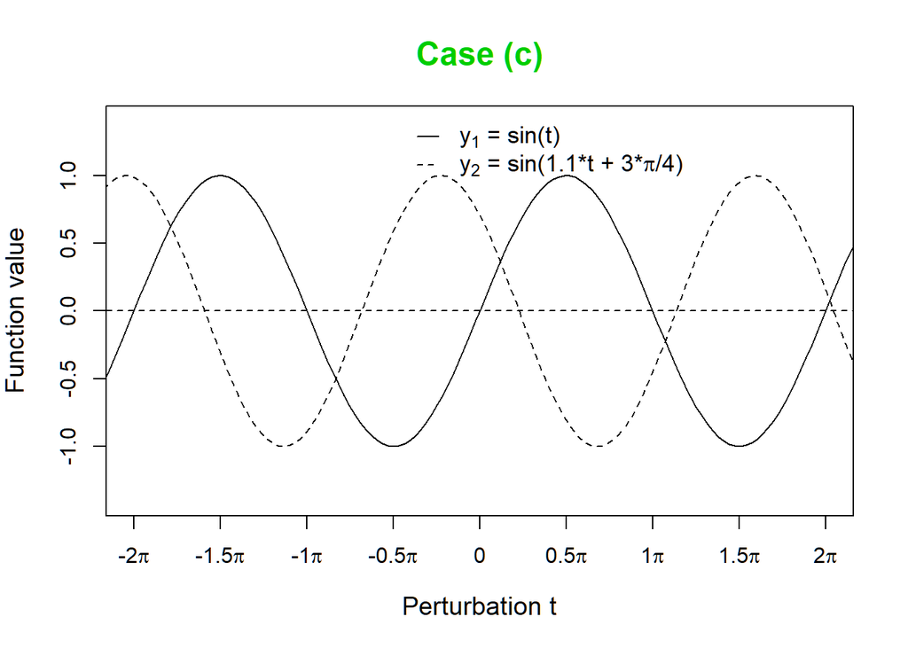

```r
ft1 <- fft(y1)[1:(length(y1) - 1) %/% 2 + 1]
ft2 <- fft(y2)[1:(length(y2) - 1) %/% 2 + 1]

FT2 <- ft1 %*% Conj(ft2)

## Re(FT2) is only close to but not actual 0,
## because the correlated data uses discrete values.

y1 <- sin(Pert)
y2 <- sin(1.1 * Pert + 3 * pi/4)

plot(Pert, y1, t = "l", col = 1,
     xlab = "Perturbation t", ylab = "Function value", axes = FALSE,
     xlim = c(-2*pi, 2*pi), ylim = c(-1.4, 1.4),
     cex.lab = 1.2, cex.axis = 1.1)
lines(Pert, y2, col = 1, lty = 2)
title("Case (c)", col.main = 3, cex.main = 1.5)
axis(1, seq(-2*pi, 2*pi, pi/2), xlab)
axis(2, seq(-1, 1, 0.5))
abline(h = 0, lty = 2)
box()

legend(-0.4 * pi, 1.5, c(expression(paste(y[1], " = sin(t)")),
                         expression(paste(y[2], " = sin(1.1*t + 3*", pi, "/4)"))),
       col = 1, pch = NA, lty = c(1, 2), bty = "n", seg.len = 1, cex = 1.1)
```

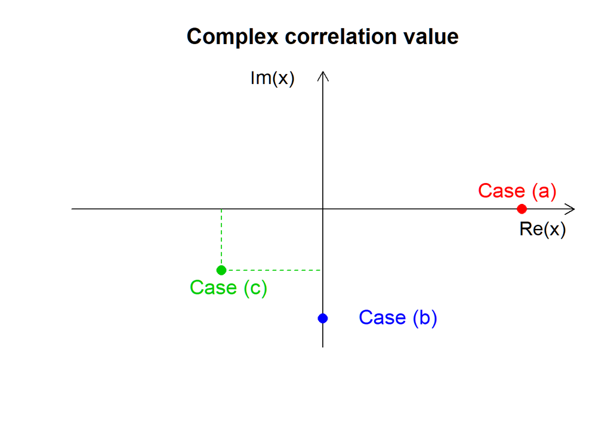

```r
ft1 <- fft(y1)[1:(length(y1) - 1) %/% 2 + 1]
ft2 <- fft(y2)[1:(length(y2) - 1) %/% 2 + 1]

FT3 <- ft1 %*% Conj(ft2)

plot(FT1, t = "n", col = 1,
     axes = FALSE, xlab = "", ylab = "",
     xlim = c(-40000, 40000), ylim = c(-40000, 40000),
     main = "Complex correlation value", xaxs = "i", yaxs = "i",
     cex.main = 1.5)
arrows(-40000, 0, 40000, 0, length = 0.125)
arrows(0, -40000, 0, 40000, length = 0.125)
points(FT1, col = 2, pch = 16, cex = 1.5)
points(FT2, col = 4, pch = 16, cex = 1.5)
points(FT3, col = 3, pch = 16, cex = 1.5)

lines(c(Re(FT3), 0), c(Im(FT3), Im(FT3)), col = 3, lty = 2)
lines(c(Re(FT3), Re(FT3)), c(Im(FT3), 0), col = 3, lty = 2)

text(35000, -6000, "Re(x)", cex = 1.3)
text(-8000, 38000, "Im(x)", cex = 1.3)
text(31000, 5000, "Case (a)", col = 2, cex = 1.4)
text(12000, -31750, "Case (b)", col = 4, cex = 1.4)
text(-15000, -23000, "Case (c)", col = 3, cex = 1.4)
```

```r
dev.off()
```

#### Section 3: Turtorial and interpretation

```r
## Loading example data
## Illustrating dataset and doing simple 2D correlation

data("FuranMale", package = "corr2D")

FuranMale[, 1:5]
```

```
##        1550.26392    1550.74602   1551.22812   1551.71023  1552.19233
## 110  0.0058962811  5.506783e-03 0.0051347609 0.0047584418 0.004295668
## 120  0.0043970716  4.860985e-03 0.0052363316 0.0055872210 0.005806852
## 130  0.0055330645  4.916008e-03 0.0045517037 0.0043091089 0.004450099
## 140 -0.0008350893 -4.653592e-04 0.0003397819 0.0014053808 0.002903903
## 150 -0.0005203668  3.312193e-05 0.0003998590 0.0008810001 0.001332789
## 160  0.0060360763  6.776913e-03 0.0073772994 0.0076989039 0.007883910
```

```r
twod <- corr2d(FuranMale)
```

```
## HOMO-Correlation: 8 cores used for calculation
## 19:20:50 - using mean values as reference
## 19:20:50 - Fast Fourier Transformation and multiplication
##  to obtain a 145 x 145 correlation matrix
## 19:20:50 - Done
```

```r
plot_corr2d(twod)
```

```
## [1] 3
```

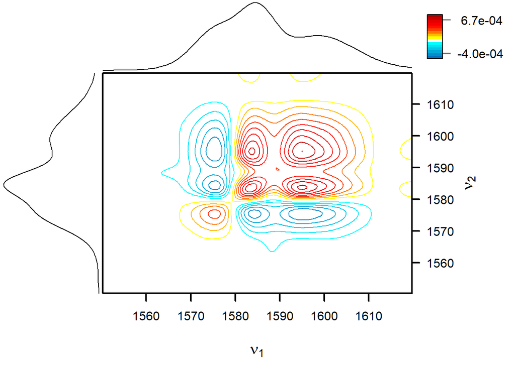

```
## [1] 3
```

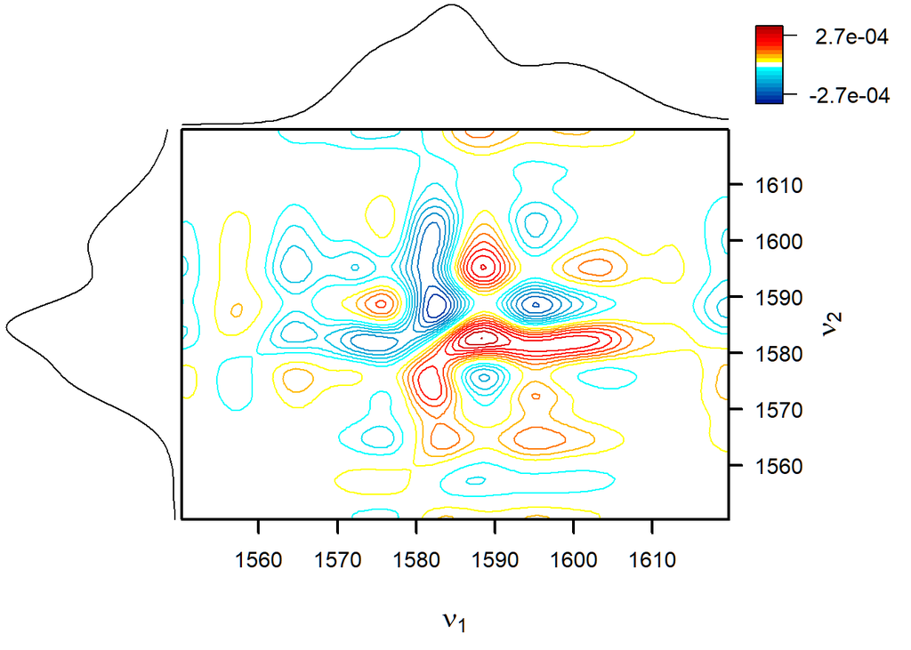

```r
plot(twod, Im(twod$FT))
```

```
## [1] 3
```

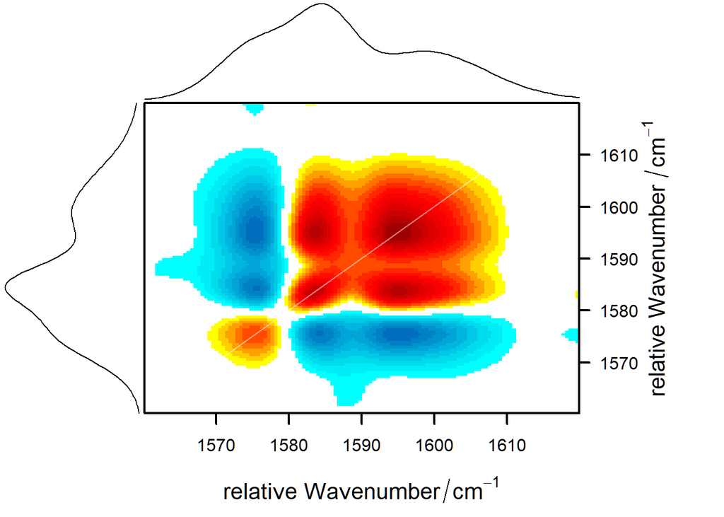

```r
plot(twod, Re(twod$FT), xlim = c(1560, 1620), ylim = c(1560, 1620),
  xlab = expression(paste("relative Wavenumber" / cm^-1)),
  ylab = expression(paste("relative Wavenumber" / cm^-1)),
  Contour = FALSE, N = 32, Cutout = c(-0.8 * 10^-4, 1.3 * 10^-4),
  Legend = FALSE)
```

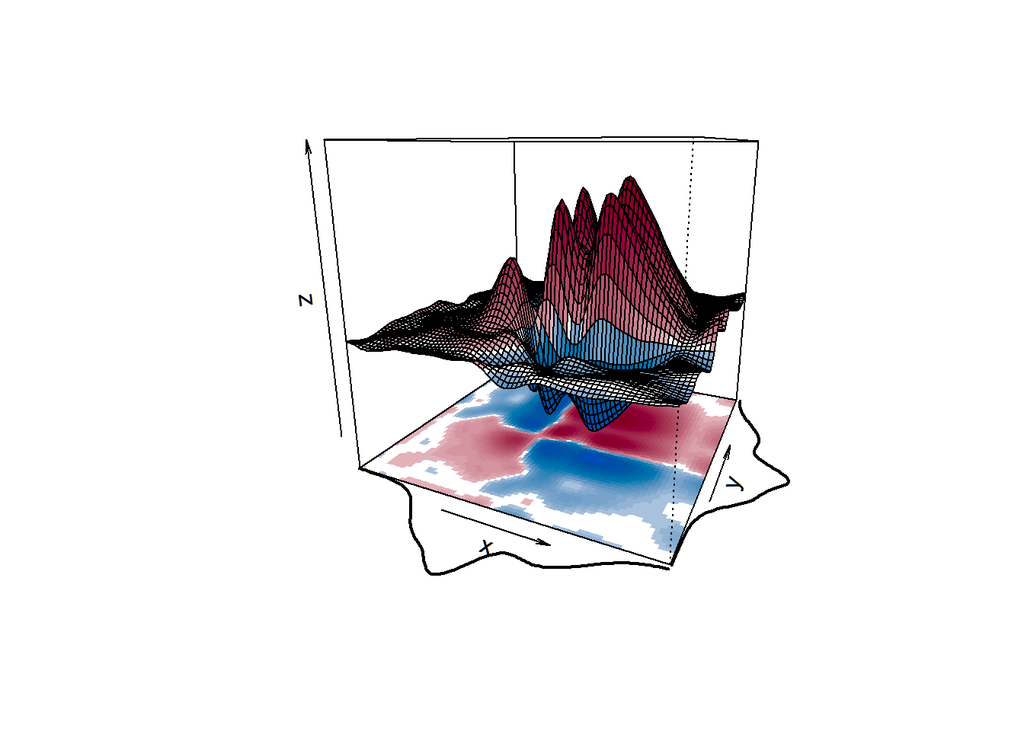

```r
plot_corr2din3d(Mat = Re(twod$FT), specx = twod$Ref1,
  specy = twod$Ref1, reduce = 2, scalex = -150, scaley = -130,
  zlim = c(-0.7, 1) * 10^-3, projection = TRUE,
  border = NULL, theta = 25, phi = 15, add.legend = FALSE,
  Col = colorspace::diverge_hcl(129, h = c(240, 0), c = 100,
  l = c(20, 100), power = 0.3))
```

#### Section 4.2: Speed test of calculation

```r
FILE <- "Speedtest-Table1.txt"
if (!file.exists(FILE)) {
    speed <- array(NA, c(6, 5, 3))
    core <- c(1, 2, 4)
    perturbation <- c(5, 10, 20, 100, 500)
    specvar <- c(200, 400, 600, 1000, 4000, 8000)

    for (i in 1:3) {
        for (j in 1:5) {
            for (k in 1:6) {
                speed[k, j, i] <- testcorr2d(specvar[k], perturbation[j], core[i], 10)
            }
        }
    }
    write.table(speed, file = FILE, col.names = FALSE, row.names = FALSE)
}
```

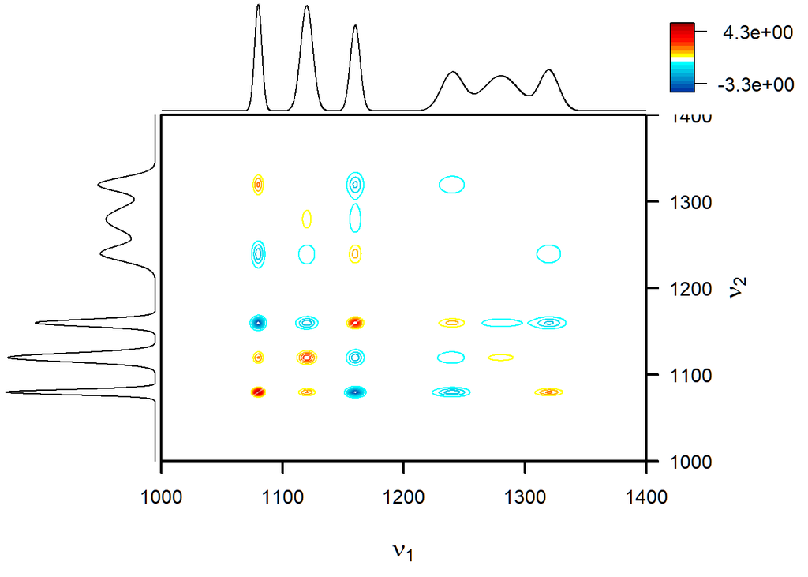

```r
simdata <- sim2ddata(4000, seq(0, 10, length.out = 100))

prof2d <- profr(c(speedtwod <- corr2d(simdata, Time =
  as.numeric(rownames(simdata)), scaling = 0.5), plot_corr2d(speedtwod)),
  interval = 0.005)
close.screen(all.screens = TRUE)
```

```r
dev.off()
```

```r
profdata <- subset(prof2d, f == "corr2d" | f == "plot_corr2d" |
  f == "apply" | f == "sapply" | f == "parallel::parCapply")

tmp1 <- which(profdata[, 4] == "apply")
tmp2 <- which(profdata[, 4] == "sapply")
tmp3 <- which(profdata[, 4] == "parallel::parCapply")
tmp4 <- which(profdata[, 4] == "corr2d")
tmp5 <- which(profdata[, 4] == "plot_corr2d")

tmpmat <- matrix(c(profdata[tmp4[1], 5], profdata[tmp1[1], 5],
  profdata[tmp1[1], 5], profdata[tmp1[1], 6],
  profdata[tmp1[1], 6], profdata[tmp2[1], 6],
  profdata[tmp2[1], 6], profdata[tmp3[1], 5],
  profdata[tmp3[1], 5], profdata[tmp3[1], 6],
  profdata[tmp3[1], 6], profdata[tmp4[1], 6],
  profdata[tmp5[1], 5], profdata[tmp5[1], 6]), 7, 2, byrow = TRUE)

time2d <- tmpmat[, 2] - tmpmat[, 1]

proftime <- cbind(c(time2d[1], 0, 0, time2d[4:6], 0),
  c(time2d[1:6], 0), time2d)

rownames(proftime) <- c("makeCluster", "Interpolation", "Reference",
  "FFT", "Correlation", "Saving", "Plot")
colnames(proftime) <- c("w/o", "w/", "Plot")


bp <- barplot(proftime, horiz = TRUE,
  names.arg = c("Corr. w/o interpol. \n or ref. calc",
    "Corr. w/ interpol. \n and ref. calc", "Corr. and plot"),
  col = colorspace::heat_hcl(8, c(0, 300), c(100, 100), c(60, 30), c(1, 1))[1:7],
  xlim = c(0, 1.2 * tmpmat[7, 2]), xlab = "Calculation time / s")

text(tmpmat[6, 2] + tmpmat[1, 2] - tmpmat[3, 2], bp[1],
     paste(round(tmpmat[6, 2] + tmpmat[1, 2] - tmpmat[3, 2], 1), "s"), pos = 4)
text(tmpmat[6, 2], bp[2], paste(round(tmpmat[6, 2], 1), "s"), pos = 4)
text(tmpmat[7, 2], bp[3], paste(round(tmpmat[7, 2], 1), "s"), pos = 4)

box()

legend(0.8 * tmpmat[7, 2], bp[1] + 1, rownames(proftime),
       col = colorspace::heat_hcl(8, c(0, 300), c(100, 100), c(60, 30), c(1, 1))[1:7], pch = 15, cex = 1.2)
```

[output not shown]

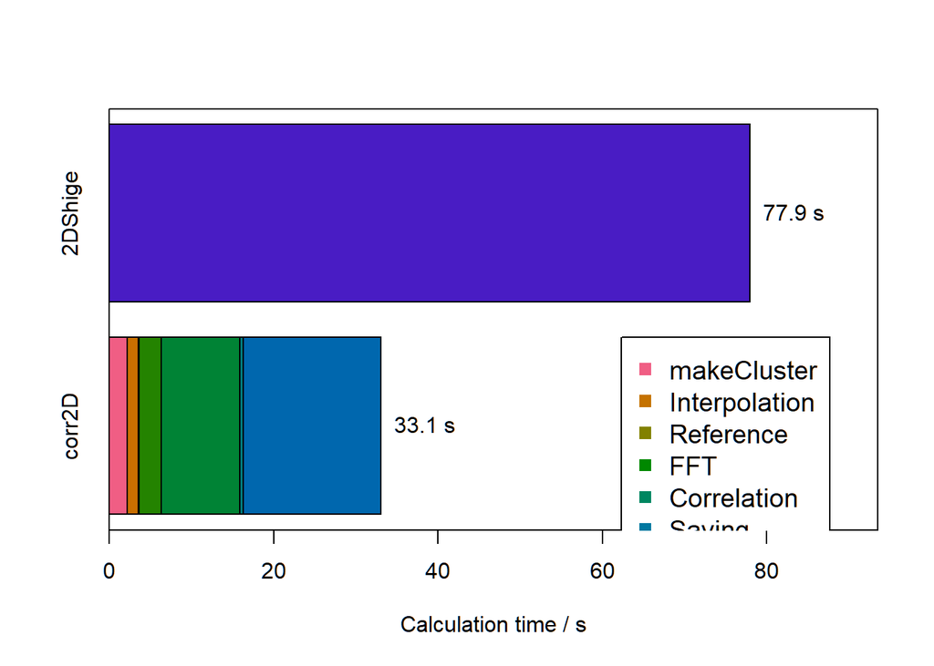

```r
shigedata <- c(79, 78, 78, 77, 78, 78, 78, 77, 78, 78)

bp <- barplot(cbind(c(time2d, 0), c(rep(0, 7), mean(shigedata))), horiz = TRUE,
  names.arg = c("corr2D", "2DShige"),
  col = colorspace::heat_hcl(8, c(0, 270), c(100, 100), c(60, 30), c(1, 1)),
  xlim = c(0, 1.2 * mean(shigedata)), xlab = "Calculation time / s")

text(tmpmat[7, 2], bp[1], paste(round(tmpmat[7, 2], 1), "s"), pos = 4)
text(mean(shigedata), bp[2], paste(round(mean(shigedata), 1), "s"), pos = 4)

box()

legend(0.8 * mean(shigedata), (bp[1] + bp[2]) / 2 - 0.1, rownames(proftime),
  col = colorspace::heat_hcl(8, c(0, 300), c(100, 100), c(60, 30), c(1, 1))[1:7], pch = 15, cex = 1.2)
```

## epinet: An R Package to Analyze Epidemics Spread across Contact Networks

### Info

The R package *epinet* provides tools for analyzing the spread of epidemics through populations. We assume that the relationships among individuals in a population are modeled by a contact network described by an exponential-family random graph model and that the disease being studied spreads across the edges of this network from infectious to susceptible individuals.

### Tests

The code is attached to the article. Every part (apart from the code which may take several hours to run) is concerning other test shown in the article.

#### Simulated Example

```r
# Load package
library("epinet")
```

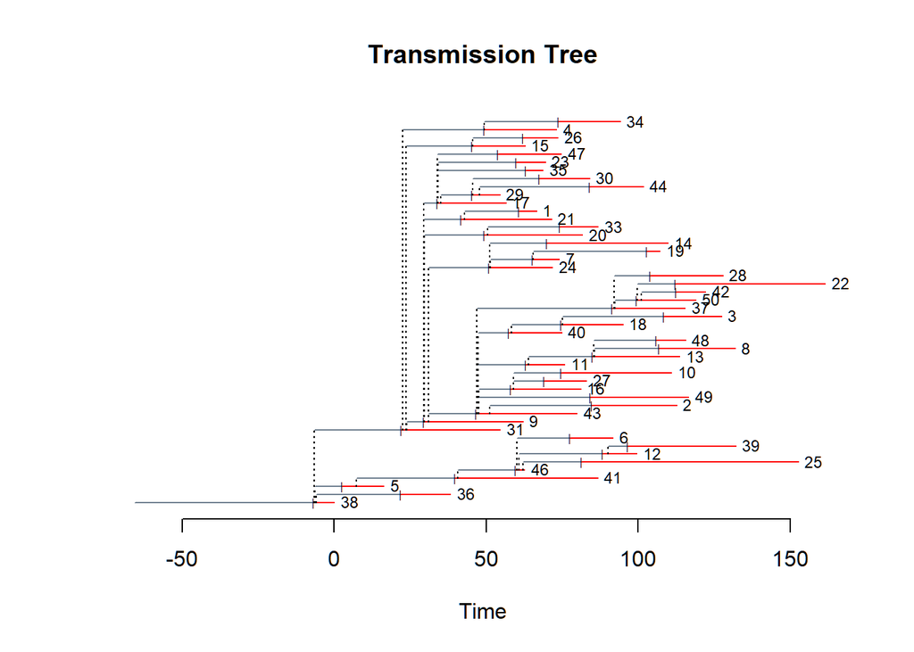

```r
N <- 50
mycov <- data.frame(id = 1:N, xpos = runif(N), ypos = runif(N))
dyadCov <- BuildX(mycov, binaryCol = list(c(2, 3)), binaryFunc = "euclidean")

# Build network
eta <- c(0, -7)
net <- SimulateDyadicLinearERGM(N = N, dyadiccovmat = dyadCov, eta = eta)


# Simulate epidemic
epi <- SEIR.simulator(M = net, N = N, beta = 1, ki = 3, thetai = 7, ke = 3, latencydist = "gamma")
# Plot epidemic
plot(epi, e.col = "slategrey", i.col = "red")
```

```r
# Run MCMC routine on simulated epidemic
mcmcinput <- MCMCcontrol(nsamp = 1000000, thinning = 100, etapropsd = c(1, 1))
priors <- priorcontrol(bprior = c(0, 4), tiprior = c(1, 15), teprior = c(1, 15), etaprior = c(0, 10, 0, 10), kiprior = c(1, 7), keprior = c(1, 7), priordists = "uniform")
out <- epinet(~ xpos.ypos.L2Dist, epidata = epi, dyadiccovmat = dyadCov, mcmcinput = mcmcinput, priors = priors)
```

```
## epinet run started at  2020-04-01 19:22:00
##
##  Initial parameter values
## ------------------------------
## Beta =  2
## eta_ 0  =  0
## eta_ 1  =  0
## Theta_I =  8
## Theta_E =  8
## k_I =  4
## k_E =  4
##
## Epidemic data:  48 infecteds, 2 susceptibles,  50 total individuals.
##
## Re-sorted dyadic covariates.
```

[output cut: 106 more lines]

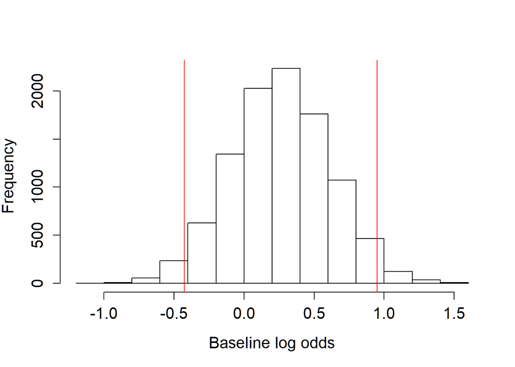

```r
# Produce histograms for posterior distributions of network parameters
hist(out$eta[, 1], main = "", xlab = "Baseline log odds", cex.axis = 1.3, cex.lab = 1.3)
abline(v = sort(out$eta[, 1])[length(out$eta[, 1]) * 0.025], col = 2)
abline(v = sort(out$eta[, 1])[length(out$eta[, 1]) * 0.975], col = 2)
```

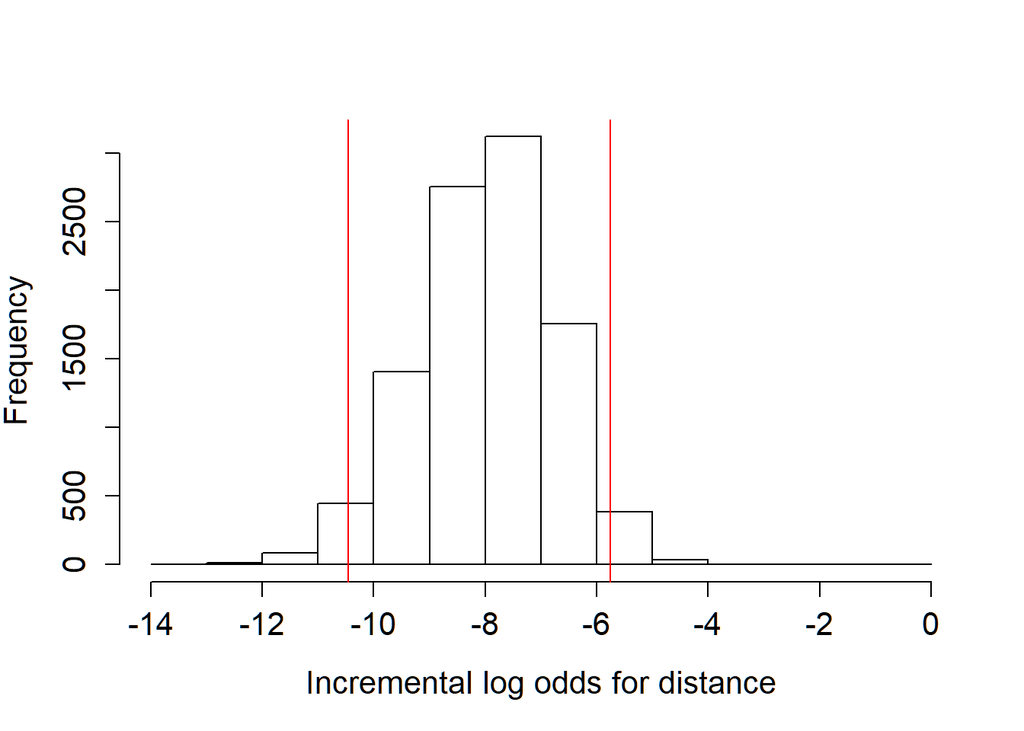

```r
hist(out$eta[, 2], main = "", xlab = "Incremental log odds for distance", cex.axis = 1.3, cex.lab = 1.3)
abline(v = sort(out$eta[, 2])[length(out$eta[, 2]) * 0.025], col = 2)
abline(v = sort(out$eta[, 2])[length(out$eta[, 2]) * 0.975], col = 2)
```

#### Hagelloch Example

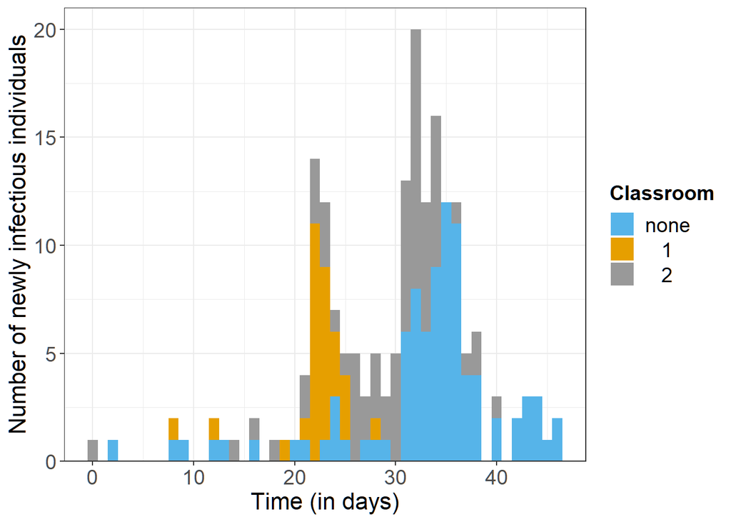

```r
library("ggplot2")
load("SuppPlotData.RData")
indivdata$Classroom <- factor(indivdata$Classroom, 2:0)
cbPalette <- c("#56B4E9", "#E69F00", "#999999")
dataplot <- ggplot(indivdata, aes(Itime - min(Itime))) +
    geom_histogram(aes(fill = Classroom), binwidth = 1) +
    scale_x_continuous(name = "Time (in days)") +
    scale_y_continuous(name = "Number of newly infectious individuals",
                       limits = c(0, 21), expand = c(0, 0)) +
    scale_fill_manual(values = cbPalette, breaks = c("0", "1", "2"),
                      labels = c("none", "   1", "   2")) + theme_bw() +
    theme(axis.text = element_text(size = 14),
          axis.title = element_text(size = 16)) +
    theme(legend.title = element_text(size = 14, face = "bold")) +
    theme(legend.text = element_text(size = 14))
dataplot
```

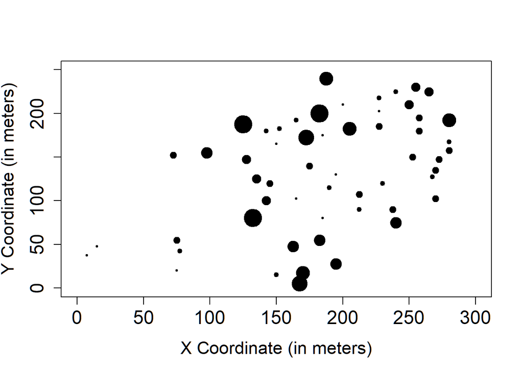

```r
# Produce Hagelloch spatial plot

plot(spatdata$X, spatdata$Y,
     xlab = "X Coordinate (in meters)", ylab = "Y Coordinate (in meters)",
     cex.lab = 1.4, cex.axis = 1.5, pch = 19,
     xlim = c(0, 300), ylim = c(0, 250), cex = spatdata$Num/2.5)
```

## Bibliography

1. Robert Geitner, Robby Fritzsch, Jürgen Popp, Thomas W. Bocklitz, *corr2D: Implementation of Two-Dimensional Correlation Analysis in R*, https://www.jstatsoft.org/article/view/v090i03
2. Chris Groendyke, David Welch, *epinet: An R Package to Analyze Epidemics Spread across Contact Networks* https://www.jstatsoft.org/article/view/v083i11